# Reul_Quantification

Rebecca Waag

18 6 2023

# Quantification of ChIP data

The Reul dataset contains results from a GR and MR ChIP experiment. Perform differential analysis, to figure out which peaks are differently bound between the individual groups under stress. The Reul dataset contains 3 groups of animals: 1 - Early morning baseline 2 - Acute stress (15 min), tissue collected after 30 min, also performed at early morning 3 - Later afternoon baseline

We will focus on comparing acute stress and early morning baseline (control), to find those regions that GR binds to under stress.

```r
suppressPackageStartupMessages({
  library(epiwraps)
  library(motifmatchr)
  library(MotifDb)
  library(universalmotif)
  library(sechm)
  library(BiocParallel)
  library(ggplot2)
  library(chromVAR) # for motif accessibility estimation
  library(SummarizedExperiment) # data structure
  library(edgeR)
  library(rtracklayer)
  library(scales)
})
```

[output not shown]

```
## See system.file("LICENSE", package="MotifDb") for use restrictions.
```

```r
# to control multithreading, unix users can use:
register(MulticoreParam(4))
```

## Perform Differential analysis on bound regions

### Import SE object

As the experiment was performed in rats, we are working with read counts per matrix where the coordinates were already converted to mouse coordinates. Several peaks were lost during this process.

```r
#load SE mouse from Reul dataset
se_Reul <- readRDS("/mnt/bohacek/Reul_MrGr_ChIP_GSE126510/peakCounts.SE.lifted2GRCm38.rds")
#class(se_Reul) #SE object
#rowRanges(se_Reul) #GRanges object with 11228 ranges

#use target and condition as factors
se_Reul$target <-as.factor(se_Reul$target)
#levels(se_Reul$target) #[1] "GR" "MR"
se_Reul$condition<-as.factor(se_Reul$condition)
#levels(se_Reul$condition) #[1] "Acute_stress"            "Early_morning_baseline"  "Late_afternoon_baseline"

#visualize sequencing depth
#barplot(se_Reul$depth)

#add peak ranges as row names to SE object
row.names(se_Reul) <- as.character(granges(se_Reul))

#extracting the individual peaks from the se_Reul object
#peaksR <- lapply(setNames(colnames(se_Reul), colnames(se_Reul)), FUN=function(x) rowRanges(se_Reul)[assays(se_Reul)$hasPeak[,x]])
#length(peaksR) #contains 24 Granges

#create consensus peaks
#merged_peaksR <- reduce(unlist(GRangesList(peaksR)), with.revmap=TRUE)
#length(merged_peaksR) #7902

#remove blacklisted regions from consensus peaks
#blacklist <- import("/reference/Mus_musculus/GRCm38.blacklist.bed")
#merged_peaksR <- merged_peaksR[!overlapsAny(merged_peaksR, blacklist)]
#length(merged_peaksR) #7891

#only keep peaks that appear in at least 3 samples
#merged_peaksR <- merged_peaksR[lengths(merged_peaksR$revmap)>=3]
#length(merged_peaksR) #3658
```

### Data Exploration

Explore data and visualize the differences in region counts using PCA.

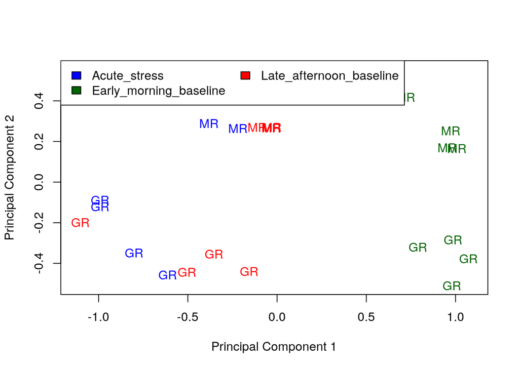

FIGURE 1: PCA of peak counts

```r
#plot PCA of experiment visualizing
colors <- c("blue", "darkgreen", "red", "black")
plotMDS(se_Reul, col=colors[se_Reul$condition], labels=se_Reul$target, gene.selection="common")
legend("topleft", fill=colors, legend=levels(se_Reul$condition), col=colors, ncol=2)
```

### Subset SE object for GR and MR

```r
#subset summarized experiment for GR
#se_Reul$target
se_Reul_GR <- se_Reul[, se_Reul$target == "GR"]
#se_Reul_GR

#specify control condition
se_Reul_GR$condition
```

```
##  [1] Late_afternoon_baseline Early_morning_baseline  Acute_stress
##  [4] Late_afternoon_baseline Early_morning_baseline  Acute_stress
##  [7] Late_afternoon_baseline Early_morning_baseline  Acute_stress
## [10] Early_morning_baseline  Acute_stress            Late_afternoon_baseline
## Levels: Acute_stress Early_morning_baseline Late_afternoon_baseline
```

```r
se_Reul_GR$condition<-relevel(se_Reul_GR$condition, "Early_morning_baseline")

#give names to regions, by default there are no rownames, use row.names
row.names(se_Reul_GR) <- as.character(granges(se_Reul_GR))

#extracting the individual GR peaks
peaksReul_GR <- lapply(setNames(colnames(se_Reul_GR), colnames(se_Reul_GR)), FUN=function(x) rowRanges(se_Reul_GR)[assays(se_Reul_GR)$hasPeak[,x]])

#create consensus peaks
merged_peaksGR <- reduce(unlist(GRangesList(peaksReul_GR)), with.revmap=TRUE)
length(merged_peaksGR) #4592
```

```
## [1] 4592
```

```r
#remove blacklisted regions from consensus peaks
blacklist <- import("/reference/Mus_musculus/GRCm38.blacklist.bed")
merged_peaksGR <- merged_peaksGR[!overlapsAny(merged_peaksGR, blacklist)]
length(merged_peaksGR) #4586
```

```
## [1] 4586
```

```r
#subset summarized experiments for MR
se_Reul_MR <- se_Reul[, se_Reul$target == "MR"]
se_Reul_MR
```

```
## class: RangedSummarizedExperiment
## dim: 11228 12
## metadata(0):
## assays(2): counts hasPeak
## rownames(11228): 2:181981490-181981564 5:109686043-109686115 ...
##   11:3466442-3466528 16:18963522-18963644
## rowData names(1): bias
## colnames(12): SRX5371943.GSM3602776.Late_afternoon_baseline_MR
##   SRX5371945.GSM3602752.Early_morning_baseline_MR ...
##   SRX5371973.GSM3602782.Acute_stress_MR
##   SRX5371976.GSM3602785.Late_afternoon_baseline_MR
## colData names(3): depth target condition
```

```r
#specify control condition
se_Reul_MR$condition
```

```
##  [1] Late_afternoon_baseline Early_morning_baseline  Acute_stress
##  [4] Late_afternoon_baseline Early_morning_baseline  Acute_stress
##  [7] Late_afternoon_baseline Early_morning_baseline  Acute_stress
## [10] Early_morning_baseline  Acute_stress            Late_afternoon_baseline
## Levels: Acute_stress Early_morning_baseline Late_afternoon_baseline
```

```r
se_Reul_MR$condition<-relevel(se_Reul_MR$condition, "Early_morning_baseline")

#give names to regions, by default there are no rownames, use row.names
row.names(se_Reul_MR) <- as.character(granges(se_Reul_MR))

#extracting the individual MR peaks
peaksReul_MR <- lapply(setNames(colnames(se_Reul_MR), colnames(se_Reul_MR)), FUN=function(x) rowRanges(se_Reul_MR)[assays(se_Reul_MR)$hasPeak[,x]])
length(peaksReul_MR) #12 samples
```

```
## [1] 12
```

```r
#create consensus peaks
merged_peaksMR <- reduce(unlist(GRangesList(peaksReul_MR)), with.revmap=TRUE)
length(merged_peaksMR) #6453
```

```
## [1] 6453
```

```r
#remove blacklisted regions from consensus peaks
#blacklist <- import("/reference/Mus_musculus/GRCm38.blacklist.bed")
merged_peaksMR <- merged_peaksMR[!overlapsAny(merged_peaksMR, blacklist)]
length(merged_peaksMR) #6442
```

```
## [1] 6442
```

### Differential analysis with edgeR (GR)

```r
#prepare DGE object
y <- DGEList(counts=assays(se_Reul_GR)$counts)

#calulate normalizaiton, assumptions are met in this experiment, so we can use TMM normalization
y <- calcNormFactors(y)

#filter by expression
#y <- y[filterByExpr(y,group=se_Reul_MR$condition),]

#specify model matrix
mm <- model.matrix(~ condition, data=as.data.frame(colData(se_Reul_GR)))
#we use an intercept here, meaning that we compare against the control

#estimate dispersion
y <- estimateDisp(y,mm)
y$common.dispersion #
```

```
## [1] 0.04729672
```

```r
#plot dispersion estimates
#plotBCV(y)

#fit model
fit <- glmQLFit(y, mm)

#check coefficients
colnames(mm)
```

```
## [1] "(Intercept)"                      "conditionAcute_stress"
## [3] "conditionLate_afternoon_baseline"
```

```r
#[1] "(Intercept)"                      "conditionAcute_stress"            "conditionLate_afternoon_baseline"

#get results
results_GR <- list()

#compare stress vs. early-morning
results_GR[["Reul.stress"]] <- glmQLFTest(fit, coef="conditionAcute_stress")
topTags(results_GR[["Reul.stress"]])
```

```
## Coefficient:  conditionAcute_stress
##                           logFC    logCPM        F       PValue          FDR
## 17:28517708-28518622   2.901152 10.939334 252.3915 2.701150e-14 2.435243e-10
## 2:167844404-167845362  3.694424  8.838751 241.8000 4.337804e-14 2.435243e-10
## 7:17057978-17058675    3.686026  8.835790 230.6102 7.307098e-14 2.734803e-10
## 7:63896652-63897487    3.269199 10.042919 217.6521 1.376705e-13 3.864412e-10
## 3:88030444-88031042    4.017888  8.191170 199.7178 3.508074e-13 7.877730e-10
## 11:51915852-51916545   2.875297  8.765823 185.9118 7.598433e-13 1.421920e-09
## 11:113806783-113807596 2.639238  9.312338 181.2265 9.993026e-13 1.602881e-09
## 10:59973937-59974730   2.568297  9.274631 173.7607 1.566873e-12 2.199106e-09
## 15:84639317-84640029   2.962434  8.648734 165.4888 2.632135e-12 3.283734e-09
## 12:55491686-55492569   2.409648  9.495564 158.4133 4.178228e-12 4.691314e-09
```

```r
summary(decideTests(results_GR[["Reul.stress"]]))
```

```
##        conditionAcute_stress
## Down                    1092
## NotSig                  8161
## Up                      1975
```

```r
#       conditionAcute_stress
#Down                    1092
#NotSig                  8161
#Up                      1975

sum(results_GR$Reul.stress$table$FDR<0.05) #3067
```

```
## [1] 0
```

```r
#compare late afternoon vs. early-morning
results_GR[["Reul.afternoon"]] <- glmQLFTest(fit, coef="conditionLate_afternoon_baseline")
topTags(results_GR[["Reul.afternoon"]])
```

```
## Coefficient:  conditionLate_afternoon_baseline
##                           logFC    logCPM        F       PValue          FDR
## 7:17057978-17058675    3.712362  8.835790 233.3725 6.410952e-14 6.732788e-10
## 2:167844404-167845362  3.503221  8.838751 217.8446 1.363479e-13 6.732788e-10
## 17:28517708-28518622   2.640010 10.939334 212.3807 1.798928e-13 6.732788e-10
## 7:63896652-63897487    3.087125 10.042919 195.7715 4.353508e-13 1.222030e-09
## 11:51915852-51916545   2.862252  8.765823 183.8520 8.564381e-13 1.923217e-09
## 3:88030444-88031042    3.598211  8.191170 159.3707 3.920877e-12 7.337268e-09
## 10:59973937-59974730   2.429764  9.274631 155.9359 4.933026e-12 7.912574e-09
## 11:113806783-113807596 2.420968  9.312338 153.3068 5.898635e-12 8.278735e-09
## 15:84639317-84640029   2.810269  8.648734 148.9893 7.957850e-12 9.927860e-09
## 12:55491686-55492569   2.279255  9.495564 142.1565 1.298460e-11 1.457911e-08
```

```r
summary(decideTests(results_GR[["Reul.afternoon"]]))
```

```
##        conditionLate_afternoon_baseline
## Down                                426
## NotSig                             9350
## Up                                 1452
```

```r
#       conditionLate_afternoon_baseline
#Down                                426
#NotSig                             9350
#Up                                 1452

sum(results_GR$Reul.afternoon$table$FDR<0.05) #1878
```

```
## [1] 0
```

```r
#calculate fdr
for(i in names(results_GR)){
  results_GR[[i]]$table$FDR <- p.adjust(results_GR[[i]]$table$PValue, method = "fdr")
}

#calculate which regions are overlapping between FSS and Double-hit hits
length(Reduce(intersect, list(which(results_GR$Reul.stress$table$FDR<0.05),which(results_GR$Reul.afternoon$table$FDR<0.05)))) #1686
```

```
## [1] 1686
```

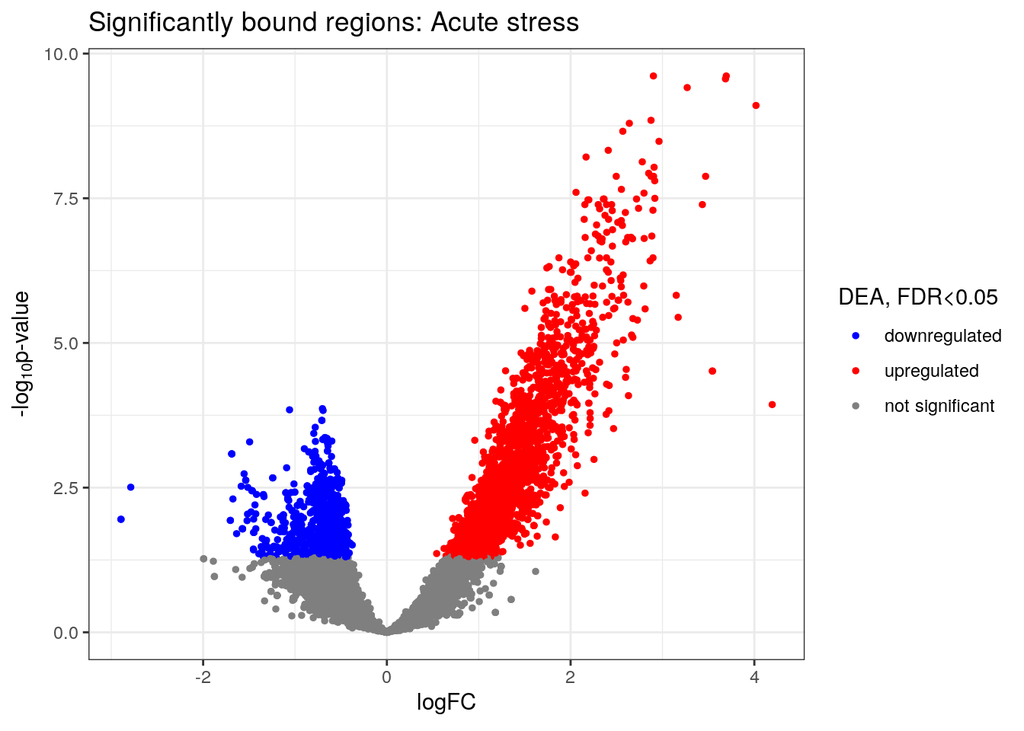

FIGURE 2: Volcanoplot showing significantly bound regions by GR between control and acutely-stressed animals

```r
#look at data using volcano plot to show regions with increased or decreased accessibility of acute stress
#classify sign. up and downregulated peaks
results_GR$Reul.stress$table$diff[results_GR$Reul.stress$table$FDR < 0.05 & results_GR$Reul.stress$table$logFC >0] <- "UP"
results_GR$Reul.stress$table$diff[results_GR$Reul.stress$table$FDR < 0.05 & results_GR$Reul.stress$table$logFC <0] <- "DOWN"

#visualize results
ggplot(results_GR$Reul.stress$table, aes(logFC, -log10(FDR), col=results_GR$Reul.stress$table$diff)) + geom_point(size=1) + theme_bw() + scale_color_manual(values = c("blue", "red"), labels =c ("downregulated", "upregulated", "not significant")) + ggtitle('Significantly bound regions: Acute stress') + labs(color = 'DEA, FDR<0.05', x = expression("logFC"), y = expression("-log"[10]*"p-value"))
```

```
## `use_raster` is automatically set to TRUE for a matrix with more than
## 2000 rows. You can control `use_raster` argument by explicitly setting
## TRUE/FALSE to it.
##
## Set `ht_opt$message = FALSE` to turn off this message.
```

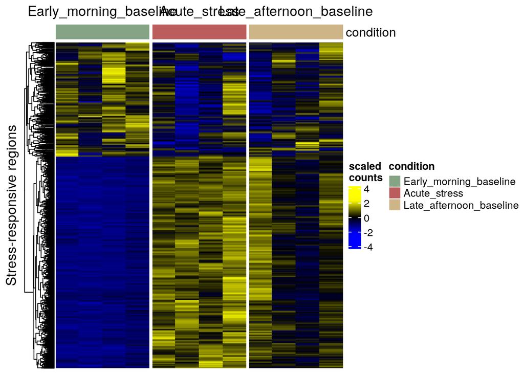

FIGURE 3: Heatmap showing differentially-bound regions by GR between control and acutely-stressed animals

```r
#add metadata column to SE object to define colors
metadata(se_Reul_GR)$anno_colors$condition <- c(Acute_stress="#BB5D5D", Early_morning_baseline= "#85A385", Late_afternoon_baseline="#CEB588")

#visualize counts in heatmap
sechm(se_Reul_GR,features = rownames(topTags(results_GR$Reul.stress, n = Inf, p.value = 0.05)), do.scale=TRUE, assayName="counts", row_title="Stress-responsive regions", gaps_at = "condition", cluster_rows = TRUE, top_annotation=c("condition"))
```

```r
#extract peaks from GR SE
GRpeaks<- granges(se_Reul_GR)
#length(MRpeaks) #11228 peaks

#subset all significant GR peaks
peaksR_GR_stress_sig <- GRpeaks[which(results_GR[["Reul.stress"]]$table$FDR<0.05)]
#dim(results_GR[["Reul.stress"]]$table) #11228 5
#length(peaksR_GR_stress_sig) #3067 peaks

#subset sign. upregulated peaks
peaksR_GR_stress_sigup <- GRpeaks[which((results_GR[["Reul.stress"]]$table$FDR<0.05) & (results_GR[["Reul.stress"]]$table$logFC>0))]
#length(peaksR_GR_stress_sigup) #1975

#subset sign. downregulated peaks
peaksR_GR_stress_sigdown <- GRpeaks[which((results_GR[["Reul.stress"]]$table$FDR<0.05) & (results_GR[["Reul.stress"]]$table$logFC<0))]
#length(peaksR_GR_stress_sigdown) #1092

#save peaks
saveRDS(merged_peaksGR, file="merged_peaksGR.rds")
saveRDS(peaksR_GR_stress_sig, file="peaksR_GR_stress_sig.rds")
saveRDS(peaksR_GR_stress_sigup, file="peaksR_GR_stress_sigup.rds")
saveRDS(peaksR_GR_stress_sigdown, file="peaksR_GR_stress_sigdown.rds")
```

3067 regions show differential binding by GR upon stress exposure, of these, 1975 regions show an increase in binding (Fig. 2 & 3). Upon time of the day, 1878 regions are differentially bound by GR. 1686 of these regions overlap between the stress and afternoon condition.

## Enrichment analysis GR peaks

Importantly, the detected regions from previously contains also counts of regions that were exclusively called on the MR peaks (as this was a combined se object), therefore, we first reduce our results to those peaks that are found in the individual peaks from the Reul GR dataset. This way, we will lose some of the peaks. All peaks called on the GR samples will serve as the background.

```r
#perform enrichment analysis
library(rGREAT)
#the background should be all accessible regions, therefore, we use the merged peaks as background
#send data to the GREAT server to run an enrichment analysis
#give names to regions, by default there are no rownames, use row.names
seqlevelsStyle(merged_peaksGR) <- "UCSC"
seqlevelsStyle(peaksR_GR_stress_sigup) <- "UCSC"

#subset those GR signup peaks that have peaks called on the GR data (not also MR)
peaksR_GR_stress_sigup <- subsetByOverlaps(peaksR_GR_stress_sigup,merged_peaksGR, type="equal") #1695

#drop weird chromosome names and clean up Granges for rGREAT
seqnames(merged_peaksGR)
```

```
## factor-Rle of length 4586 with 24 runs
##   Lengths:            338            360 ...             18              2
##   Values : chr2           chr5           ... chrY           chrUn_GL456381
## Levels(24): chr2 chr5 chr10 chr14 ... chrUn_GL456387 chrY chrUn_GL456381
```

```r
chrom <- c("chr1", "chr10", "chr11", "chr12", "chr13", "chr14", "chr15", "chr16", "chr17", "chr18", "chr19", "chr2", "chr3", "chr4", "chr5", "chr6", "chr7", "chr8", "chr9", "chrX", "chrY")
merged_peaksGR_chrom<- keepSeqlevels(merged_peaksGR, value=chrom, pruning.mode="coarse")
length(merged_peaksGR_chrom) #4580
```

```
## [1] 4580
```

```r
names(merged_peaksGR_chrom) <-NULL
seqnames(peaksR_GR_stress_sigup)
```

```
## factor-Rle of length 1695 with 80 runs
##   Lengths:    20     2     6     6    67 ...     1     1    24     8    23
##   Values : chr10 chr13 chr10 chr17 chr7  ... chr2  chr3  chr1  chr17 chrX
## Levels(24): chr2 chr5 chr10 chr14 ... chrUn_GL456387 chrY chrUn_GL456381
```

```r
peaksR_GR_stress_sigup_chrom<- keepSeqlevels(peaksR_GR_stress_sigup, value=chrom, pruning.mode="coarse")
length(peaksR_GR_stress_sigup_chrom) #1695
```

```
## [1] 1695
```

```r
names(peaksR_GR_stress_sigup_chrom) <-NULL

#get enrichment results for upregulated peaks
job_GR_up <- rGREAT::submitGreatJob(gr=peaksR_GR_stress_sigup_chrom, bg=merged_peaksGR_chrom, species="mm10") #we use mm10, cause GRCm38 is not supported
res_GR_up <- rGREAT::getEnrichmentTables(job_GR_up)
```

```
## The default enrichment tables contain no associated genes for the input
## regions. You can set `download_by = 'tsv'` to download the complete
## table, but note only the top 500 regions can be retreived. See the
## following link:
##
## https://great-help.atlassian.net/wiki/spaces/GREAT/pages/655401/Export#Export-GlobalExport
```

```r
#res_GR_up

#plot the top 20 Biological processes
bp_GR_up <- res_GR_up$`GO Biological Process`
#bp_GR_up
sum(bp_GR_up$Hyper_Adjp_BH<0.05) #451 GO terms are sign. enriched
```

```
## [1] 451
```

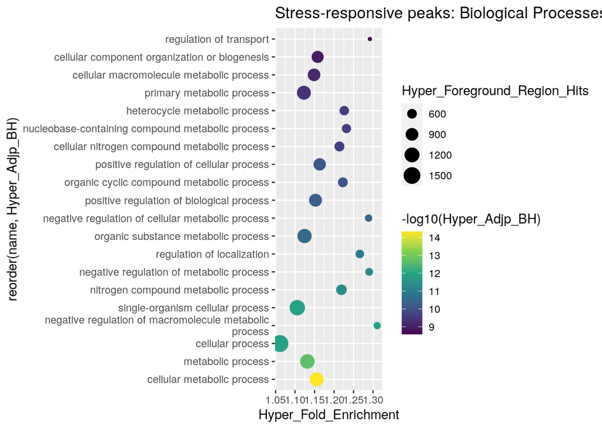

FIGURE 4: Enrichment analysis of significantly more bound GR peaks

```r
ggplot(head(bp_GR_up,20), aes(Hyper_Fold_Enrichment, reorder(name, Hyper_Adjp_BH), size=Hyper_Foreground_Region_Hits, color=-log10(Hyper_Adjp_BH))) + geom_point() + scale_color_viridis_c() + ggtitle("Stress-responsive peaks: Biological Processes") + scale_y_discrete(labels = label_wrap(50))
```

```r
#save shortened peaks
saveRDS(peaksR_GR_stress_sigup, file="peaksR_GR_stress_sigup_sh.rds")
peaksR_GR_stress_sigdown <- subsetByOverlaps(peaksR_GR_stress_sigdown,merged_peaksGR, type="equal") #1695
saveRDS(peaksR_GR_stress_sigdown, file="peaksR_GR_stress_sigdown_sh.rds")
```

From the enrichment analysis performed on the significantly more bound regions upon stress, no clear pattern arises, metabolic processes in general seem to be affected (Fig. 4).

## Standard differential analysis of MR peaks using edgeR

```r
#prepare DGE object
y <- DGEList(counts=assays(se_Reul_MR)$counts)

#calulate normalizaiton, assumptions are met in this experiment, so we can use TMM normalization
y <- calcNormFactors(y)

#filter by expression
#y <- y[filterByExpr(y,group=se_Reul_MR$condition),]

#specify model matrix
mm <- model.matrix(~ condition, data=as.data.frame(colData(se_Reul_MR)))
#we use an intercept here, meaning that we compare against the control

#estimate dispersion
y <- estimateDisp(y,mm)
y$common.dispersion #
```

```
## [1] 0.04000485
```

```r
#plot dispersion estimates
#plotBCV(y)

#fit model
fit <- glmQLFit(y, mm)

#check coefficients
colnames(mm)
```

```
## [1] "(Intercept)"                      "conditionAcute_stress"
## [3] "conditionLate_afternoon_baseline"
```

```r
#[1] "(Intercept)"                      "conditionAcute_stress"            "conditionLate_afternoon_baseline"

#get results
results_MR <- list()

#compare stress vs. early-morning
results_MR[["Reul.stress"]] <- glmQLFTest(fit, coef="conditionAcute_stress")
topTags(results_MR[["Reul.stress"]])
```

```
## Coefficient:  conditionAcute_stress
##                           logFC   logCPM         F       PValue          FDR
## 7:17057978-17058675    2.989796 8.090903 199.73172 2.708851e-14 3.041498e-10
## 2:167844404-167845362  2.714141 7.877721 135.04348 3.030887e-12 1.701540e-08
## 15:84639317-84640029   2.306899 7.872186 126.51245 6.478982e-12 2.273689e-08
## 9:48723385-48724283    2.026234 8.591235 124.09146 8.100067e-12 2.273689e-08
## 2:30671339-30672026    2.397437 8.474856 116.92457 1.603188e-11 3.600120e-08
## 7:63896652-63897487    1.635698 9.601201 101.53742 7.851722e-11 1.469319e-07
## 11:113806783-113807596 1.850087 8.341973  90.10307 2.908353e-10 3.898779e-07
## 12:55491686-55492569   1.912074 9.005775  89.51409 3.121979e-10 3.898779e-07
## 17:28420002-28420676   2.270412 7.066072  89.50572 3.125134e-10 3.898779e-07
## 10:59969579-59970481   1.760732 8.189748  81.49828 8.504463e-10 9.548811e-07
```

```r
summary(decideTests(results_MR[["Reul.stress"]]))
```

```
##        conditionAcute_stress
## Down                     351
## NotSig                  9586
## Up                      1291
```

```r
#       conditionAcute_stress
#Down                     351
#NotSig                  9586
#Up                      1291

sum(results_MR$Reul.stress$table$FDR<0.05) #1642
```

```
## [1] 0
```

```r
#compare late afternoon vs. early-morning
results_MR[["Reul.afternoon"]] <- glmQLFTest(fit, coef="conditionLate_afternoon_baseline")
topTags(results_MR[["Reul.afternoon"]])
```

```
## Coefficient:  conditionLate_afternoon_baseline
##                           logFC   logCPM         F       PValue          FDR
## 7:17057978-17058675    3.160337 8.090903 225.38380 6.013419e-15 6.751867e-11
## 2:167844404-167845362  2.696045 7.877721 134.29322 3.235042e-12 1.816153e-08
## 7:63896652-63897487    1.789529 9.601201 121.62977 1.020258e-11 2.866000e-08
## 9:48723385-48724283    1.998716 8.591235 121.62188 1.021019e-11 2.866000e-08
## 15:84639317-84640029   2.136993 7.872186 109.23051 3.469178e-11 6.996363e-08
## 11:51915852-51916545   1.929173 7.908953 108.50701 3.738705e-11 6.996363e-08
## 2:30671339-30672026    2.201240 8.474856  99.27512 1.007723e-10 1.481990e-07
## 11:106268226-106268819 1.992717 7.156059  98.85600 1.055925e-10 1.481990e-07
## 12:55491686-55492569   1.869136 9.005775  86.12975 4.724958e-10 5.894647e-07
## 3:88030444-88031042    2.210349 7.069084  79.31473 1.131900e-09 1.270897e-06
```

```r
summary(decideTests(results_MR[["Reul.afternoon"]]))
```

```
##        conditionLate_afternoon_baseline
## Down                                226
## NotSig                             9927
## Up                                 1075
```

```r
#       conditionLate_afternoon_baseline
#Down                                226
#NotSig                             9927
#Up                                 1075

sum(results_MR$Reul.afternoon$table$FDR<0.05) #1301
```

```
## [1] 0
```

```r
#calculate fdr
for(i in names(results_MR)){
  results_MR[[i]]$table$FDR <- p.adjust(results_MR[[i]]$table$PValue, method = "fdr")
}

#calculate which regions are overlapping between FSS and Double-hit hits
length(Reduce(intersect, list(which(results_MR$Reul.stress$table$FDR<0.05),which(results_MR$Reul.afternoon$table$FDR<0.05)))) #987
```

```
## [1] 987
```

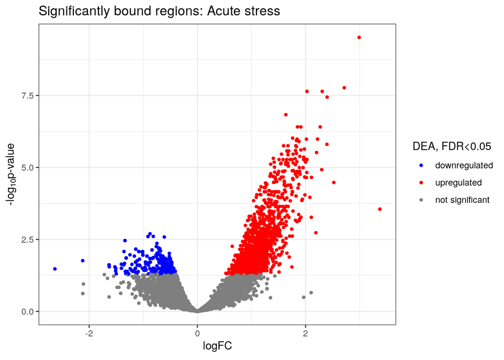

FIGURE 5: Volcanoplot showing significantly bound regions by MR between control and acutely-stressed animals

```r
#look at data using volcano plot to show regions with increased or decreased accessibility of acute stress
#classify sign. up and downregulated peaks
results_MR$Reul.stress$table$diff[results_MR$Reul.stress$table$FDR < 0.05 & results_MR$Reul.stress$table$logFC >0] <- "UP"
results_MR$Reul.stress$table$diff[results_MR$Reul.stress$table$FDR < 0.05 & results_MR$Reul.stress$table$logFC <0] <- "DOWN"

#visualize results
ggplot(results_MR$Reul.stress$table, aes(logFC, -log10(FDR), col=results_MR$Reul.stress$table$diff)) + geom_point(size=1) + theme_bw() + scale_color_manual(values = c("blue", "red"), labels =c ("downregulated", "upregulated", "not significant")) + ggtitle('Significantly bound regions: Acute stress') + labs(color = 'DEA, FDR<0.05', x = expression("logFC"), y = expression("-log"[10]*"p-value"))
```

1642 regions show differential binding by MR upon stress exposure, of these, 1291 regions show an increase in binding (Fig. 5). Upon time of the day, 1301 regions are differentially bound by MR. 987 of these regions overlap between the stress and afternoon condition.

```
## `use_raster` is automatically set to TRUE for a matrix with more than
## 2000 rows. You can control `use_raster` argument by explicitly setting
## TRUE/FALSE to it.
##
## Set `ht_opt$message = FALSE` to turn off this message.
```

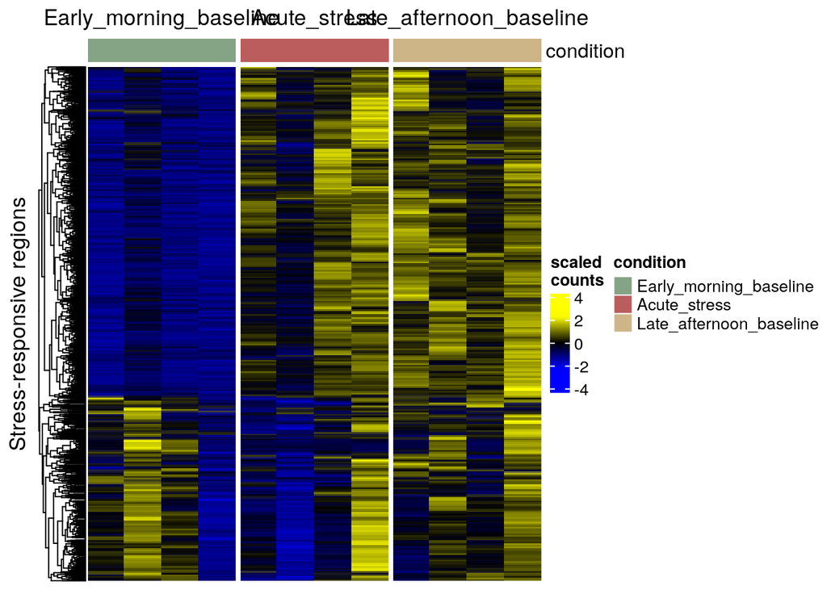

```r
#add metadata column to SE object to define colors
metadata(se_Reul_MR)$anno_colors$condition <- c(Acute_stress="#BB5D5D", Early_morning_baseline= "#85A385", Late_afternoon_baseline="#CEB588")

#visualize counts in heatmap
sechm(se_Reul_MR,features = rownames(topTags(results_GR$Reul.stress, n = Inf, p.value = 0.05)), do.scale=TRUE, assayName="counts", row_title="Stress-responsive regions", gaps_at = "condition", cluster_rows = TRUE, top_annotation=c("condition"))
```

```r
#extract peaks from MR SE
MRpeaks<- granges(se_Reul_MR)
#length(MRpeaks) #11228 peaks

#subset all significant MR peaks
peaksR_MR_stress_sig <- MRpeaks[which(results_MR[["Reul.stress"]]$table$FDR<0.05)]
#dim(results_MR[["Reul.stress"]]$table) #11228 5
length(peaksR_MR_stress_sig) #1642 peaks
```

```
## [1] 1642
```

```r
#subset sign. upregulated peaks
peaksR_MR_stress_sigup <- MRpeaks[which((results_MR[["Reul.stress"]]$table$FDR<0.05) & (results_MR[["Reul.stress"]]$table$logFC>0))]
length(peaksR_MR_stress_sigup) #1291
```

```
## [1] 1291
```

```r
#subset sign. downregulated peaks
peaksR_MR_stress_sigdown <- MRpeaks[which((results_MR[["Reul.stress"]]$table$FDR<0.05) & (results_MR[["Reul.stress"]]$table$logFC<0))]
length(peaksR_MR_stress_sigdown) #351
```

```
## [1] 351
```

```r
#save peaks
saveRDS(merged_peaksMR, file="merged_peaksMR.rds")
saveRDS(peaksR_MR_stress_sig, file="peaksR_MR_stress_sig.rds")
saveRDS(peaksR_MR_stress_sigup, file="peaksR_MR_stress_sigup.rds")
saveRDS(peaksR_MR_stress_sigdown, file="peaksR_MR_stress_sigdown.rds")
```

Visualization of the differentially-bound regions indicates that the regions being bound upon stress tend to be similar to those responding to the time of the days (later-afternoon) (Fig. 6). However, this requires further analyses, which is not included here.

## Enrichment analysis MR peaks

Importantly, the detected regions from previously contains also counts of regions that were exclusively called on the GR peaks (as this was a combined se object), therefore, we first reduce our results to those peaks that are found in the individual peaks from the Reul MR dataset. This way, we will lose some of the peaks. All peaks called on the MR samples will serve as the background.

```r
#perform enrichment analysis
library(rGREAT)
#the background should be all accessible regions, therefore, we use the merged peaks as background
#send data to the GREAT server to run an enrichment analysis
seqlevelsStyle(merged_peaksMR) <- "UCSC"
seqlevelsStyle(peaksR_MR_stress_sigup) <- "UCSC"
seqlevelsStyle(peaksR_MR_stress_sigdown) <- "UCSC"

#subset those MR signup peaks that have peaks called on the GR data (not also MR)
peaksR_MR_stress_sigup <- subsetByOverlaps(peaksR_MR_stress_sigup,merged_peaksMR, type="equal") #1157

#drop weird chromosome names and clean up Granges for rGREAT
seqnames(merged_peaksMR)
```

```
## factor-Rle of length 6442 with 23 runs
##   Lengths:            494            481 ...             19              2
##   Values : chr2           chr5           ... chrY           chrUn_GL456381
## Levels(24): chr2 chr5 chr10 chr14 ... chrUn_GL456387 chrY chrUn_GL456381
```

```r
chrom <- c("chr1", "chr10", "chr11", "chr12", "chr13", "chr14", "chr15", "chr16", "chr17", "chr18", "chr19", "chr2", "chr3", "chr4", "chr5", "chr6", "chr7", "chr8", "chr9", "chrX", "chrY")
merged_peaksMR_chrom<- keepSeqlevels(merged_peaksMR, value=chrom, pruning.mode="coarse")
length(merged_peaksMR_chrom) #6437
```

```
## [1] 6437
```

```r
names(merged_peaksMR_chrom) <-NULL
seqnames(peaksR_MR_stress_sigup)
```

```
## factor-Rle of length 1157 with 65 runs
##   Lengths:     8     1     5    62    37 ...     1     1    17     2    12
##   Values : chr10 chr13 chr17 chr7  chr19 ... chr2  chr3  chr1  chr17 chrX
## Levels(24): chr2 chr5 chr10 chr14 ... chrUn_GL456387 chrY chrUn_GL456381
```

```r
peaksR_MR_stress_sigup_chrom<- keepSeqlevels(peaksR_MR_stress_sigup, value=chrom, pruning.mode="coarse")
length(peaksR_MR_stress_sigup_chrom) #1157
```

```
## [1] 1157
```

```r
names(peaksR_MR_stress_sigup_chrom) <-NULL

#get enrichment results for upregulated peaks
job_MR_up <- rGREAT::submitGreatJob(gr=peaksR_MR_stress_sigup_chrom, bg=merged_peaksMR_chrom, species="mm10") #we use mm10, cause GRCm38 is not supported
```

```
## Don't make too frequent requests. The time break is 60s.
## Please wait for 28s for the next request.
## The time break can be set by `request_interval` argument.
```

```r
res_MR_up <- rGREAT::getEnrichmentTables(job_MR_up)
```

```
## The default enrichment tables contain no associated genes for the input
## regions. You can set `download_by = 'tsv'` to download the complete
## table, but note only the top 500 regions can be retreived. See the
## following link:
##
## https://great-help.atlassian.net/wiki/spaces/GREAT/pages/655401/Export#Export-GlobalExport
```

```r
#res_MR_up

#plot the top 20 Biological processes
bp_MR_up <- res_MR_up$`GO Biological Process`
#bp_MR_up
sum(bp_MR_up$Hyper_Adjp_BH<0.05) #146 GO terms are sign. enriched
```

```
## [1] 146
```

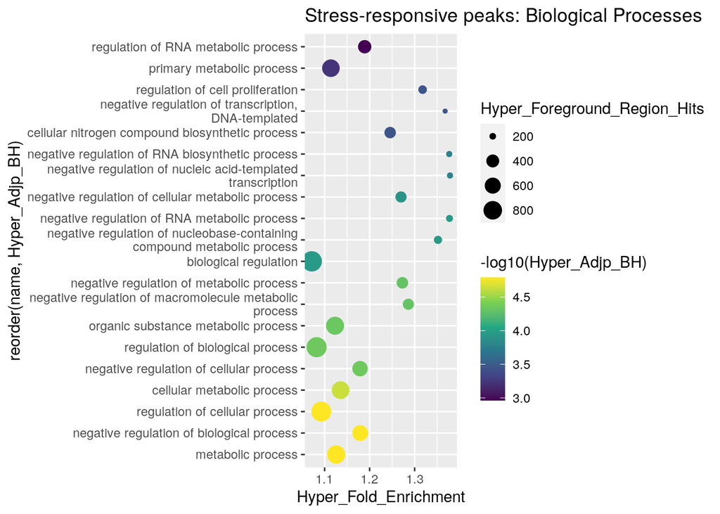

FIGURE 7: Enrichment analysis of significantly more bound MR peaks

```r
ggplot(head(bp_MR_up,20), aes(Hyper_Fold_Enrichment, reorder(name, Hyper_Adjp_BH), size=Hyper_Foreground_Region_Hits, color=-log10(Hyper_Adjp_BH))) + geom_point() + scale_color_viridis_c() + ggtitle("Stress-responsive peaks: Biological Processes") + scale_y_discrete(labels = label_wrap(50))
```

```r
saveRDS(peaksR_MR_stress_sigup, file="peaksR_MR_stress_sigup_sh.rds")
peaksR_MR_stress_sigdown <- subsetByOverlaps(peaksR_MR_stress_sigdown,merged_peaksMR, type="equal") #107
saveRDS(peaksR_MR_stress_sigdown, file="peaksR_MR_stress_sigdown_sh.rds")
```

From the enrichment analysis performed on the significantly more bound regions upon stress by MR, affected biological processes seem to be related to metabolism and negative regulation of transcription (Fig. 7).

## Compare significantly more bound peaks between GR and MR ChIP

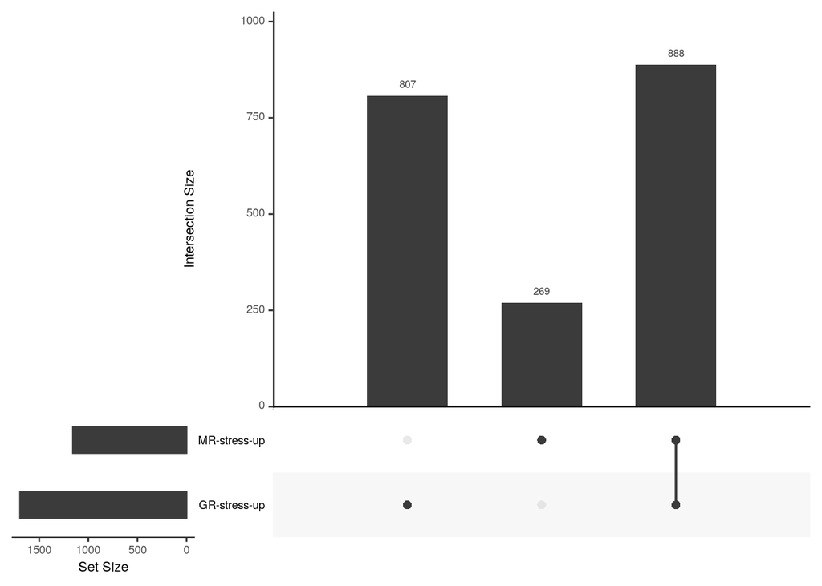

FIGURE 8: Upset plot showing overlaps of peaks between the significantly more bound MR and GR peaks

```r
#prepare object with sign. more bound peaks
GR_MR<- list("MR-stress-up" = peaksR_MR_stress_sigup, "GR-stress-up" = peaksR_GR_stress_sigup)

#plot Upsetplot
regionUpset(GR_MR)
```

A large number of peaks overlaps between the MR and GR ChIP, revealing that MR and GR bind very similar regions in the genome (Fig. 8).